# Reproducible Research: Peer Assessment 1

## Imputing missing values

Calculate and report the total number of missing values in the dataset

```r
data2<-read.csv("activity.csv", header=TRUE, na.strings=c(""))
data2$date <- as.Date(data2$date)
data2$steps <- as.numeric(as.character(data2$steps))
sum(is.na(data2$steps))
```

```
## [1] 2304
```

Devise a strategy for filling in all the missing values in the dataset. We shall use the mean value to fill in the missing data. Create a new dataset that is equal to the original dataset but with the missing data filled in.Make a histogram of the total number of steps taken each day.

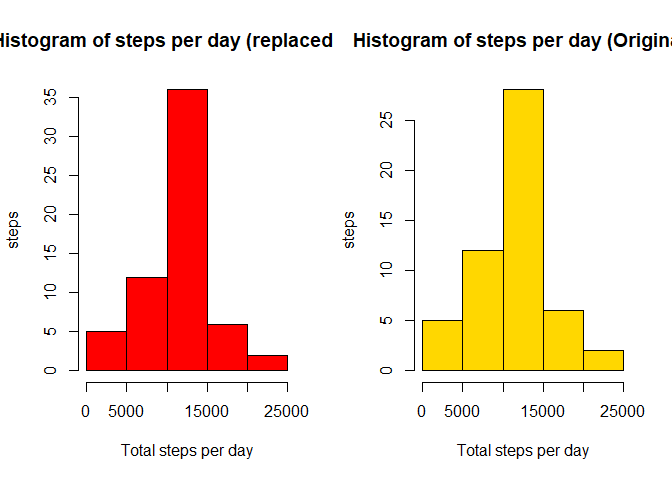

```r
data2[is.na(data2$steps), "steps"] <- mean(data$steps, na.rm=TRUE)
NewstepsPerday<- aggregate(steps~date, data2, sum, na.rm=TRUE)

par(mfrow=c(1,2))
hist(NewstepsPerday$steps, col="red", xlab="Total steps per day", ylab="steps", main="Histogram of steps per day (replaced NAs)")
hist(stepsPerday$steps, col="gold", xlab="Total steps per day", ylab="steps", main="Histogram of steps per day (Original)")
```

Calculate and report the mean and median total number of steps per day. Do these values differ from the estimates from the first part of the assignment? What is the impact of imputing missing data on the estimates of the total daily number of steps?

```r
mean(NewstepsPerday$steps)
```

```
## [1] 10766.19
```

```r
median(NewstepsPerday$steps)
```

```
## [1] 10766.19
```

(note: after imputing the missing values with mean, the mean and median seems to be aligned)

## Are there differences in activity patterns between weekdays and weekends?

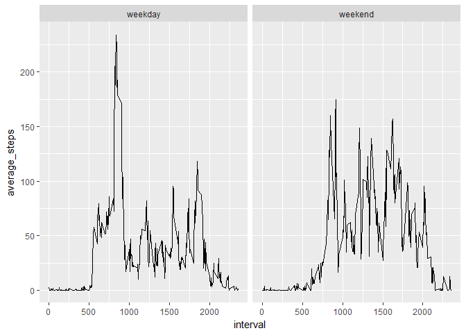

```r
data$dayType<- format(data$date, "%a")
data$dayType <- ifelse(data$dayType=="Sat"|data$dayType=="Sun", "weekend", "weekday")
average_steps_type <- aggregate(data$steps, by=list(data$interval, data$dayType), FUN=mean, na.rm=TRUE)
colnames(average_steps_type) <- c("interval", "dayType", "average_steps")
library(ggplot2)
ggplot(aes(x=interval, y=average_steps), data=average_steps_type)+geom_line()+facet_wrap(~average_steps_type$dayType)
```